# Report: Estimating the Impact of Groundwater Allocation Policies on Irrigation Behavior

Shunkei Kakimoto

```r
# === setup === #
library(here)
source(here("GitControlled/Codes/0_1_ls_packages.R"))
source(here("GitControlled/Codes/0_0_functions.R"))

# /*===== Data =====*/
reg_data_all <-
  here("Shared/Data/WaterAnalysis/comp_reg_dt.rds") %>%
  readRDS() %>%
  .[year %in% 2008:2015 & usage <= 45,] %>%
  .[,tr_year:=factor(paste0(tr,year))]


reg_data <-
  reg_data_all %>%
  .[year %in% 2008:2012]

# --- NRD boundary --- #
nrd_boud <-
 here("Shared/Data/WaterAnalysis/NRD_bd/BND_NaturalResourceDistricts_DNR.shp") %>%
 st_read() %>%
 filter(NRD_Name %in% c("Lower Republican", "Tri-Basin")) %>%
 st_transform(4269)
```

# 1 Groundwater use in LR

## 1.1 Visualize annual water usage

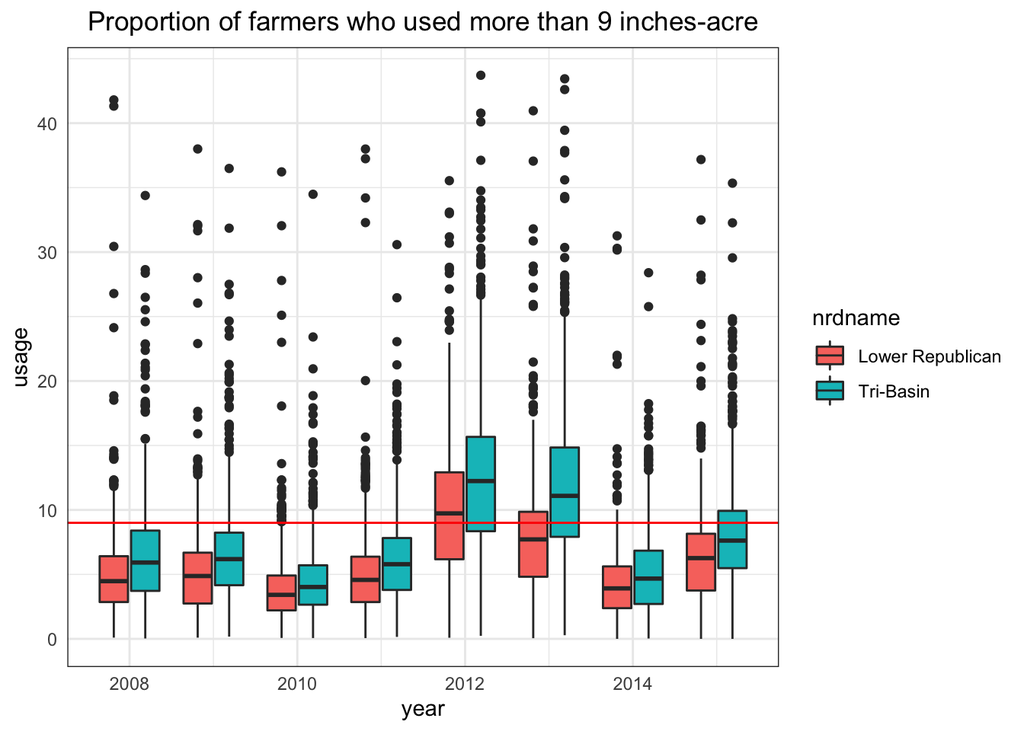

```r
# /*===== Boxplot =====*/
ggplot() +
  geom_boxplot(data = reg_data_all, aes(x=year, y= usage, group= interaction(nrdname, year), fill= nrdname)) +
  geom_hline(yintercept = 9, color="red") +
  ggtitle("Proportion of farmers who used more than 9 inches-acre") +
  theme_figure
```

```r
# /*===== How often producer in LR used more than 9 inches  =====*/
ch_reg_data <-
  reg_data_all %>%
  .[treat2==1,.(ID, year, usage)] %>%
  .[,over_9 := ifelse(usage<=9, 0, 1)] %>%
  .[, .(
    num_obs = .N,
    sum_over_9 = sum(over_9, na.rm=TRUE)
    ), by = year] %>%
  .[,prop_over_9 := sum_over_9/num_obs] %>%
  .[order(year)]
```

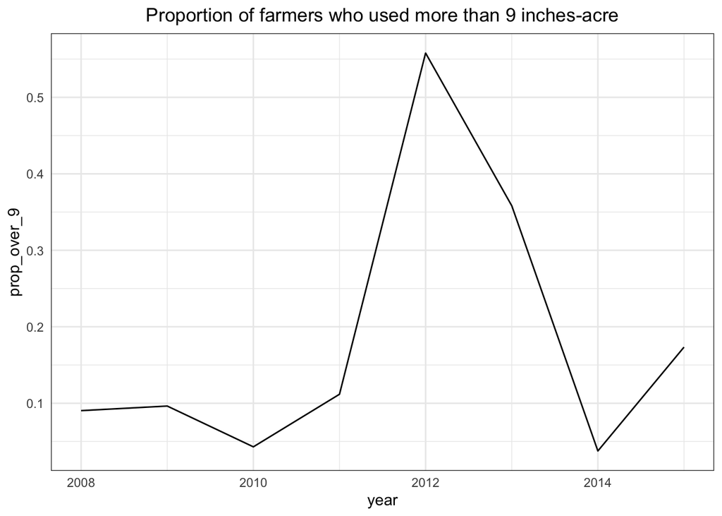

```r
ggplot(ch_reg_data)+
  geom_line(aes(x=year, y=prop_over_9)) +
  ggtitle("Proportion of farmers who used more than 9 inches-acre") +
  theme_figure
```

## 1.2 LR: Overuse Penalties

- source: “LRNRD Rules & Regulations”:(https://www.lrnrd.org/index.php/component/content/article/7-info/32-lrnrd-rules-regulations-6-1-12)
- criteria:
  - “A Landowner or Operator must have **a positive balance in his or her Allocation account before using water in any year of an Allocation Period**. The LRNRD shall notify Landowners and/or Operators anytime the balance of their Allocation goes below zero.”

## 1.3 Potential reasons for observing more than 9-inches usage.

- 1. A farmer was allowed to allocate his total allocation limit (45 inches-acre) freely across years within an Allocation Period (i.e., Pooling). A Smart farmers would have saved some of his annual groundwater usage to prepare future weather uncertainty.
- 2. **Pooling Agreement**:
  - An agreement approved by the District **between two or more Landowners** for the purpose of allocating ground water among the total combined Certified Irrigated Acres identified in such agreement.
    - For example, a farmer A (10 acres) and a farmer B (20 acres) contracted this agreement, then farmer A and B can access to (10 acres + 20 acres) * 9 acre-inches per year= 270 inches per year in total , and they can allocate this amount of water freely between their farmlands.
- 3. **Pooling Arrangement**:
  - An arrangement approced by the District by **a single landowner** to combine more than one tract of land under common ground water among the total combined Certified Irrigated Acres identified in the arrangement.
    - For example, suppose a farmer has multiple farmlands (field A :10 acres and field B: 20 acres) which are admitted as Certified Irrigated Acres. His total groundwater allocation is 270 inches per year in total ((10 acres + 20 acres) * 9 acre-inches per year= 270), and he can allocate this amount of groundwater to field A and field B freely.
- source: “LOWER REPBULICAN NATURAL RESOURCES DISTRICT AMENDED AND RESTATED GROUND WATER MANAGEMENT RULES AND REGULATIONS” - CHAPTER 7 (https://www.lrnrd.org/docman/docs/478-groundwater-rules-and-regulations-clean-3-9-17/file)